# COMPSCIX 415.2 Homework 5

Chris Boyd

2/26/2019

```r
library(mdsr)
library(dplyr)
library(tidyverse)
```

# Github link

[COMPSCIX 415.2 Homework 5](https://github.com/christopher-boyd/compscix4152/tree/master/hw)

# Table of Contents

1. Tidyverse packages
2. R Basics
3. Data Import / Export
4. Visualization
5. Data munging and wrangling
6. EDA
7. Git and Github

# Section 1: The tidyverse packages

> Can you name which package is associated with each task below?
- Plotting: **ggplot2**
- Data munging/wrangling: **dplyr**
- Reshaping (speading and gathering) data: **tidry**
- Importing/exporting data: **readr**

> Now can you name two functions that you’ve used from each package that you listed above for these tasks?
- Plotting - ggplot2: **geom_point()** and **aes()**
- Data munging/wrangling: dplyr: **filter()** and **summarise()**
- Reshaping (speading and gathering) data - tidry: **gather()** and **spread()**
- Importing/exporting data - readr: **read_csv()** and **write_delim()**

# Section 2: R Basics

> Fix this code with the fewest number of changes possible so it works:
> 1. My_data.name___is.too00ooLong! <- c( 1 , 2 , 3 )

```r
# corrected with fewest possible changes:
My_data.name___is.too00ooLong <- c( 1 , 2   , 3 )
My_data.name___is.too00ooLong
```

```
## [1] 1 2 3
```

```r
# corrected with a few more changes:
my_data <- c( 1 , 2   , 3 )
my_data
```

```
## [1] 1 2 3
```

> 2. my_string <- C(‘has’, ‘an’, ‘error’, ‘in’, ’it)

```r
# corrected with fewest possible changes:
my_string <- c('has', 'an', 'error', 'in', 'it')
```

> 3. Look at the code below and comment on what happened to the values in the vector.

```r
my_vector <- c(1, 2, '3', '4', 5)
my_vector
```

```
## [1] "1" "2" "3" "4" "5"
```

```r
typeof(my_vector)
```

```
## [1] "character"
```

Wrapping the 3 and 4 in the single quote cast each element in the vector to a ‘character’ datatype.

# Section 3: Data import/export

> 1. Download the rail_trail.txt file from Canvas (in the Midterm Exam section) and successfully import it into R. Prove that it was imported successfully by including your import code and taking a glimpse of the result.

```r
import_file_path = "../data/rail_trail.txt"
rail_trail <- read.csv(import_file_path, sep ="|", header = TRUE)
glimpse(rail_trail)
```

```
## Observations: 90
## Variables: 10
## $ hightemp   <int> 83, 73, 74, 95, 44, 69, 66, 66, 80, 79, 78, 65, 41, 5…
## $ lowtemp    <int> 50, 49, 52, 61, 52, 54, 39, 38, 55, 45, 55, 48, 49, 3…
## $ avgtemp    <dbl> 66.5, 61.0, 63.0, 78.0, 48.0, 61.5, 52.5, 52.0, 67.5,…
## $ spring     <int> 0, 0, 1, 0, 1, 1, 1, 1, 0, 0, 0, 1, 1, 0, 0, 1, 0, 1,…
## $ summer     <int> 1, 1, 0, 1, 0, 0, 0, 0, 1, 1, 1, 0, 0, 0, 0, 0, 1, 0,…
## $ fall       <int> 0, 0, 0, 0, 0, 0, 0, 0, 0, 0, 0, 0, 0, 1, 1, 0, 0, 0,…
## $ cloudcover <dbl> 7.6, 6.3, 7.5, 2.6, 10.0, 6.6, 2.4, 0.0, 3.8, 4.1, 8.…
## $ precip     <dbl> 0.00, 0.29, 0.32, 0.00, 0.14, 0.02, 0.00, 0.00, 0.00,…
## $ volume     <int> 501, 419, 397, 385, 200, 375, 417, 629, 533, 547, 432…
## $ weekday    <int> 1, 1, 1, 0, 1, 1, 1, 0, 0, 1, 1, 1, 1, 1, 1, 1, 0, 1,…
```

> 2. Export the file into a comma-separated file and name it “rail_trail.csv”. Make sure you define the path correctly so that you know where it gets saved. Then reload the file. Include your export and import code and take another glimpse.

```r
export_file_path = "../data/rail_trail.csv"

write.csv(rail_trail, file = export_file_path, row.names=FALSE)

import_file_path_csv = "../data/rail_trail.csv"
rail_trail_csv <- read_csv(import_file_path_csv, col_names = TRUE)
glimpse(rail_trail_csv)
```

```
## Observations: 90
## Variables: 10
## $ hightemp   <dbl> 83, 73, 74, 95, 44, 69, 66, 66, 80, 79, 78, 65, 41, 5…
## $ lowtemp    <dbl> 50, 49, 52, 61, 52, 54, 39, 38, 55, 45, 55, 48, 49, 3…
## $ avgtemp    <dbl> 66.5, 61.0, 63.0, 78.0, 48.0, 61.5, 52.5, 52.0, 67.5,…
## $ spring     <dbl> 0, 0, 1, 0, 1, 1, 1, 1, 0, 0, 0, 1, 1, 0, 0, 1, 0, 1,…
## $ summer     <dbl> 1, 1, 0, 1, 0, 0, 0, 0, 1, 1, 1, 0, 0, 0, 0, 0, 1, 0,…
## $ fall       <dbl> 0, 0, 0, 0, 0, 0, 0, 0, 0, 0, 0, 0, 0, 1, 1, 0, 0, 0,…
## $ cloudcover <dbl> 7.6, 6.3, 7.5, 2.6, 10.0, 6.6, 2.4, 0.0, 3.8, 4.1, 8.…
## $ precip     <dbl> 0.00, 0.29, 0.32, 0.00, 0.14, 0.02, 0.00, 0.00, 0.00,…
## $ volume     <dbl> 501, 419, 397, 385, 200, 375, 417, 629, 533, 547, 432…
## $ weekday    <dbl> 1, 1, 1, 0, 1, 1, 1, 0, 0, 1, 1, 1, 1, 1, 1, 1, 0, 1,…
```

# Section 4: Visualization

> Reproduce this graphic using the diamonds data set.

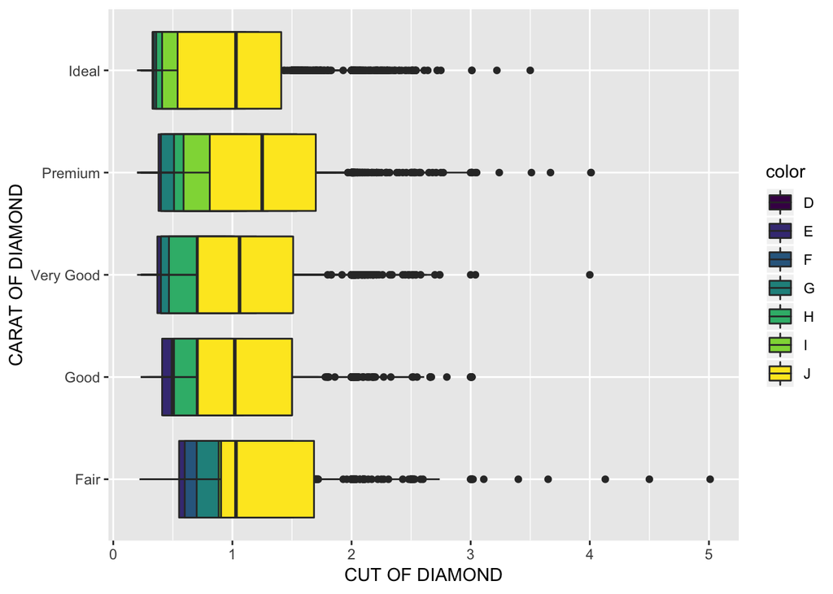

```r
ggplot(data = diamonds) +
  geom_boxplot(position="identity", aes(x = cut, y=carat, fill=color)) +
  coord_flip() +
  xlab("CARAT OF DIAMOND") +
  ylab("CUT OF DIAMOND")
```

The easiest way to make this more readable is to omit the ‘position=“identity”’ argument.

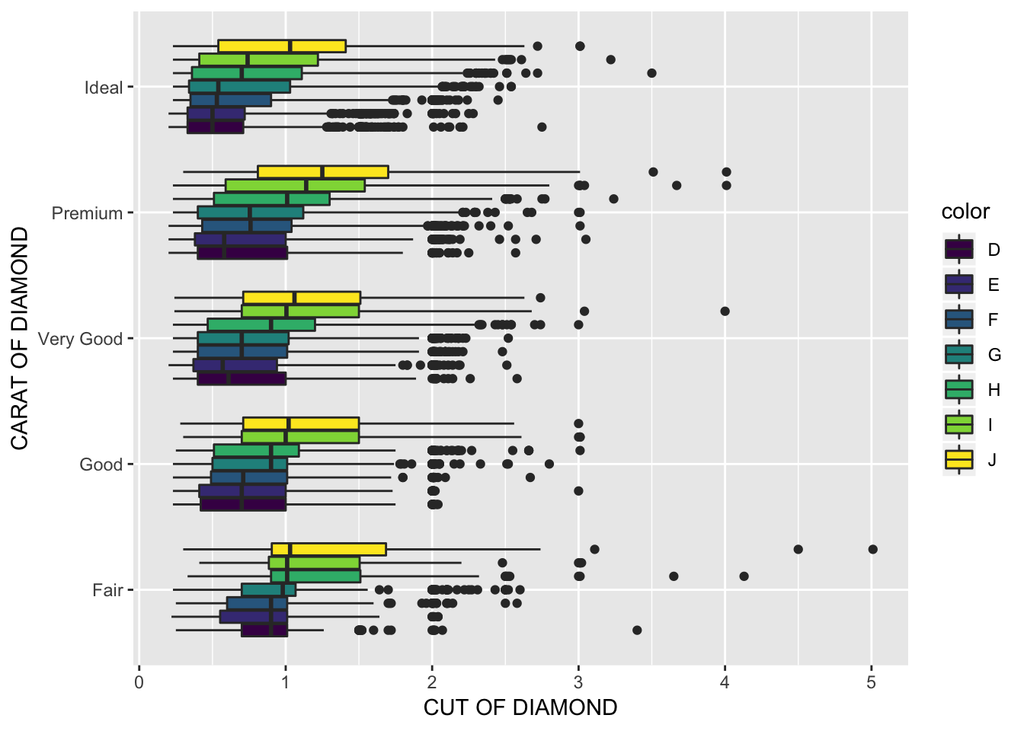

```r
ggplot(data = diamonds) +
  geom_boxplot(aes(x = cut, y=carat, fill=color)) +
  coord_flip() +
  xlab("CARAT OF DIAMOND") +
  ylab("CUT OF DIAMOND")
```

Another way is to add a facet_wrap. I think the plot above is more readable, however.

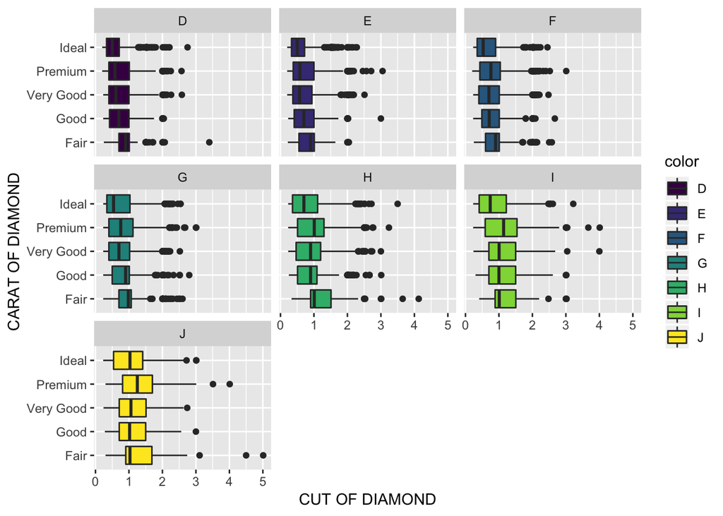

```r
ggplot(data = diamonds) +
  geom_boxplot(aes(x = cut, y=carat, fill=color)) +
  coord_flip() +
  facet_wrap(~ color) +
  xlab("CARAT OF DIAMOND") +
  ylab("CUT OF DIAMOND")
```

# Section 5: Data munging and wrangling

> Is this data “tidy”? If yes, leave it alone and go to the next problem. If no, make it tidy. Note: this data set is called table2 and is available in the tidyverse package. It should be ready for you to use after you’ve loaded the tidyverse package.

No. Type and count should be spread to make it tidy data.

```r
table2 %>%
  spread(key = type, value = count)
```

```
## # A tibble: 6 x 4
##   country      year  cases population
##   <chr>       <int>  <int>      <int>
## 1 Afghanistan  1999    745   19987071
## 2 Afghanistan  2000   2666   20595360
## 3 Brazil       1999  37737  172006362
## 4 Brazil       2000  80488  174504898
## 5 China        1999 212258 1272915272
## 6 China        2000 213766 1280428583
```

> Create a new column in the diamonds data set called price_per_carat that shows the price of each diamond per carat (hint: divide). Only show me the code, not the output.

```r
new_diamonds = mutate(diamonds, price_per_carat = price / carat)
```

> For each cut of diamond in the diamonds data set, how many diamonds, and what proportion, have a price > 10000 and a carat < 1.5? There are several ways to get to an answer, but your solution must use the data wrangling verbs from the tidyverse in order to get credit.

```r
diamonds %>%
    group_by(cut) %>%
      summarise(
        total = n(),
        total_count = count(price > 10000 & carat < 1.5),
        proportion  = total_count / total
      )
```

```
## # A tibble: 5 x 4
##   cut       total total_count proportion
##   <ord>     <int>       <int>      <dbl>
## 1 Fair       1610           4    0.00248
## 2 Good       4906          17    0.00347
## 3 Very Good 12082         155    0.0128
## 4 Premium   13791         173    0.0125
## 5 Ideal     21551         485    0.0225
```

# EDA

> Take a look at the txhousing data set that is included with the ggplot2 package and answer these questions:
> 1. During what time period is this data from?

```r
first_date = filter(txhousing, date == min(txhousing$date)) %>% slice(1:1)
last_date = filter(txhousing, date == max(txhousing$date)) %>% slice(1:1)

#start_date
paste(first_date$month, first_date$year, sep='/')
```

```
## [1] "1/2000"
```

```r
#end_date
paste(last_date$month, last_date$year, sep='/')
```

```
## [1] "7/2015"
```

Range is 1/2000 - 7/2015.

> 2. How many cities are represented?

```r
txhousing %>%
  group_by(city) %>%
    summarise %>%
      count()
```

```
## # A tibble: 1 x 1
##       n
##   <int>
## 1    46
```

There are 46 unique cities.

> 3. Which city, month and year had the highest number of sales?

```r
txhousing %>%
  group_by(city, year, month) %>%
    summarise(
      max_sales = max(sales)
    ) %>%
  arrange(desc(max_sales))
```

```
## # A tibble: 8,602 x 4
## # Groups:   city, year [736]
##    city     year month max_sales
##    <chr>   <int> <int>     <dbl>
##  1 Houston  2015     7      8945
##  2 Houston  2006     6      8628
##  3 Houston  2013     7      8468
##  4 Houston  2015     6      8449
##  5 Houston  2013     5      8439
##  6 Houston  2014     6      8391
##  7 Houston  2014     7      8391
##  8 Houston  2014     8      8167
##  9 Houston  2013     8      8155
## 10 Houston  2006     5      8040
## # … with 8,592 more rows
```

Houston July 2015 had the most sales.

> What kind of relationship do you think exists between the number of listings and the number of sales? Check your assumption and show your work.

As listings increase, so should sales and vice versa.

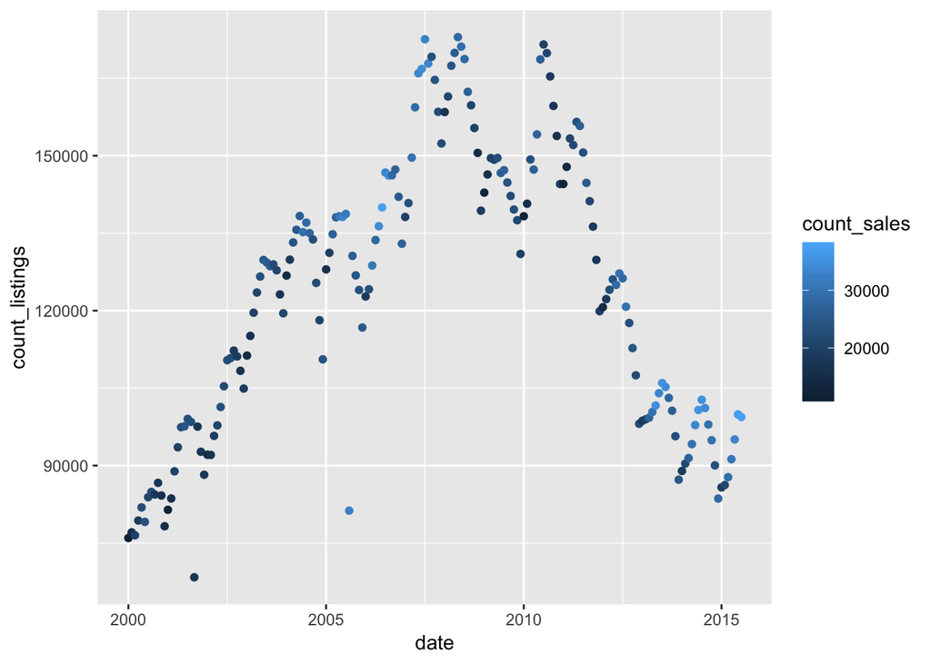

```r
txhousing %>%
  group_by(date) %>%
    summarise (
      count_sales = sum(sales, na.rm=TRUE),
      count_listings = sum(listings, na.rm=TRUE)
    ) %>%

ggplot(aes(x = date, y=count_listings)) +
  geom_point(aes(colour = count_sales))
```

> What proportion of sales is missing for each city?

```r
txhousing %>%
  group_by(city) %>%
    summarise(
      count = n(),
      missing = count(is.na(sales)),
      prop_missing = missing / count
    )
```

```
## # A tibble: 46 x 4
##    city                  count missing prop_missing
##    <chr>                 <int>   <int>        <dbl>
##  1 Abilene                 187       0       0
##  2 Amarillo                187       0       0
##  3 Arlington               187       0       0
##  4 Austin                  187       0       0
##  5 Bay Area                187       0       0
##  6 Beaumont                187       0       0
##  7 Brazoria County         187      14       0.0749
##  8 Brownsville             187       2       0.0107
##  9 Bryan-College Station   187       0       0
## 10 Collin County           187       0       0
## # … with 36 more rows
```

> Looking at only the cities and months with greater than 500 sales:

> Are the distributions of the median sales price (column name median), when grouped by city, different? The same? Show your work.

```r
txhousing %>%
    filter(sales > 500) %>%
      group_by(city) %>%
          ggplot +
            geom_boxplot(aes(x = city, y = median)) +
            coord_flip()
```

[output not shown]

```r
txhousing %>%
    filter(sales > 500) %>%
      group_by(date()) %>%
          ggplot +
            geom_boxplot(aes(x = city, y = median)) +
            coord_flip()
```

[output not shown]

```r
txhousing %>%
    filter(sales > 500) %>%
          ggplot +
            geom_boxplot(aes(x = city, y = median)) +
            coord_flip()
```

[output not shown]

> Any cities that stand out that you’d want to investigate further?

> Why might we want to filter out all cities and months with sales less than 500?

The fewer the sales, the less meaningful the median sales price.

# Git and Github

[COMPSCIX 415.2 Homework 5](https://github.com/christopher-boyd/compscix4152/tree/master/hw)